# Mitteilung: Dargebotene Hand

Details siehe [GitHub repo](https://github.com/statistikZH/covid19monitoring_social_Tel143)

2021-04-08

# Corona verändert Alltagssorgen nur wenig

**Kurze Zusammenfassung**

Die «Dargebotene Hand» bietet als Sorgentelefon Unterstützung für die Bevölkerung. Während seit jeher die Mehrheit der Anrufenden Frauen sind, melden sich im Corona-Jahr 2020 mehr Männer als im Vorjahr. Kaum etwas geändert hat sich bei den Beratungsinhalten, wobei das Thema «Suchtverhalten» die grösste Veränderung aufweist.

# Erster Paragraph (Einleitung)

Das Schweizer Sorgentelefon «Dargebotene Hand», auch bekannt als Telefon 143, ist rund um die Uhr für Menschen da, die helfende und unterstützende Gespräche benötigen. Die Gespräche finden via Chat oder Telefon statt, wobei Telefongespräche mit 93% den Löwenanteil der Kontakte ausmacht. Das regionale Sorgentelefon kümmert sich um den Kanton Zürich ohne die Bezirke Winterthur und Andelfingen, den st. gallischen Bezirk Gaster und See und den Bezirk Höfe im Kanton Schwyz. Aus aktuellem Anlass der Corona-Pandemie zeigt das Statistische Amt des Kantons Zürich in der vorliegenden Kurzanalyse, wer bei der Nummer 143 anruft und welche Beratungsinhalte gefragt sind.

## Männer rufen vermehrt an

Das Sorgentelefon hat im ersten Halbjahr 2020 rund 17600 Anrufe mit einer durchschnittlichen Gesprächsdauer von 17 Minuten entgegengenommen.. Dies entspricht fast 100 Anrufen pro Tag mit insgesamt 28 Stunden Betreuungszeit. Die Mehrheit der Anrufenden waren Frauen: Sie riefen rund zweieinhalb Mal mehr an als die Männer. Dieses Muster zeigt sich gemäss der Dargebotenen Hand schon seit Jahren: Frauen reden vermehrt über ihre Probleme, während Männer eher dazu tendieren, ihre Sorgen für sich zu behalten oder Belastungen anders zu kompensieren.

Im Vergleich zum Vorjahr sind die Zahl der Anrufe und die durchschnittliche Gesprächsdauer im ersten Halbjahr 2020 stabil geblieben. Was sich verändert hat, ist die Verteilung nach Monaten und Geschlechtern: Im Januar und im Februar nahm die Zahl der Anrufe leicht ab. Von März bis Juni nahm sie dagegen zu. Vor allem bei den Männern fällt die Zunahme deutlich aus: sie riefen rund 25% häufiger an als im selben Vorjahreszeitraum. Die Frauen meldeten sich hingegen etwas seltener beim Sorgentelefon, die Zahl ihrer Anrufe ist um 1.6% gesunken.

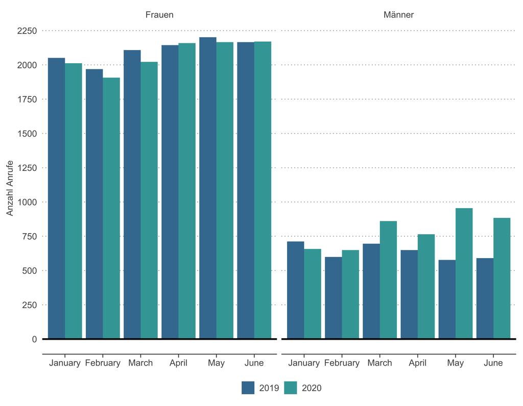

## Gegenläufige Veränderung bei Männern und Frauen

Das Sorgentelefon wird vor allem von Männern und Frauen im mittleren Alter gewählt. Jugendliche wählen die Nummer 143 kaum. Ihre Altersklasse ist allerdings auch mit Abstand am kleinsten, und für sie gibt es viele andere, teils gezielt auf Jugendliche zugeschnittene Beratungsangebote (z.B. Notrufnummer 147 von Pro Juventute). Der im ersten Halbjahr 2020 beobachtete Zuwachs der Anrufe von Männern ist vor allem in der mittleren Altersklasse ersichtlich. Frauen im mittleren Alter griffen hingegen im ersten Halbjahr 2020 seltener zum Hörer als im Vorjahr. Dafür melden sich jugendliche Frauen und Frauen im Pensionsalter vermehrt.

Weshalb es zu diesen Verlagerungen kam, ist nicht bekannt. Besonders das veränderte Verhalten der Geschlechter in der mittleren Altersklasse ist schwierig zu deuten. Dass hingegen die Frauen über 65 vermehrt anriefen, hängt wohl damit zusammen, dass sie öfter alleine leben und deshalb mehr unter dem Lockdown litten als die gleichaltrigen Männer.

**Visualisierung:** Grafik 2  
**Titel:** Anzahl Anrufe pro Altersklasse  
**Untertitel:** Nach Geschlecht und Jahr  
**Datenquelle:** Dargebotene Hand (143.ch)  
**Legende:** Anzahl Anrufe pro Altersklasse nach Geschlecht und Jahr (2019-2020).  
**Alternativtext:** Balkendiagramm mit drei Altersklassen (bis 18-Jährige, 19 bis 65-Jährige, über 65-Jährige) auf der horizontalen Achse. Anzahl Anrufe als Total zwischen Januar und Juni auf der vertikalen Achse. Bei Frauen in 2019 und 2020, 418 und 522 Anrufe in der unteren Altersklasse; 7382 und 6775 Anrufe in der mittleren Altersklasse; 3875 und 4346 Anrufe in der oberen Altersklasse. Bei Männern in 2019 und 2020, 56 und 60 Anrufe in der unteren Altersklasse; 2586 und 3410 in der mittleren Altersklasse; 850 und 879 in der oberen Altersklasse.

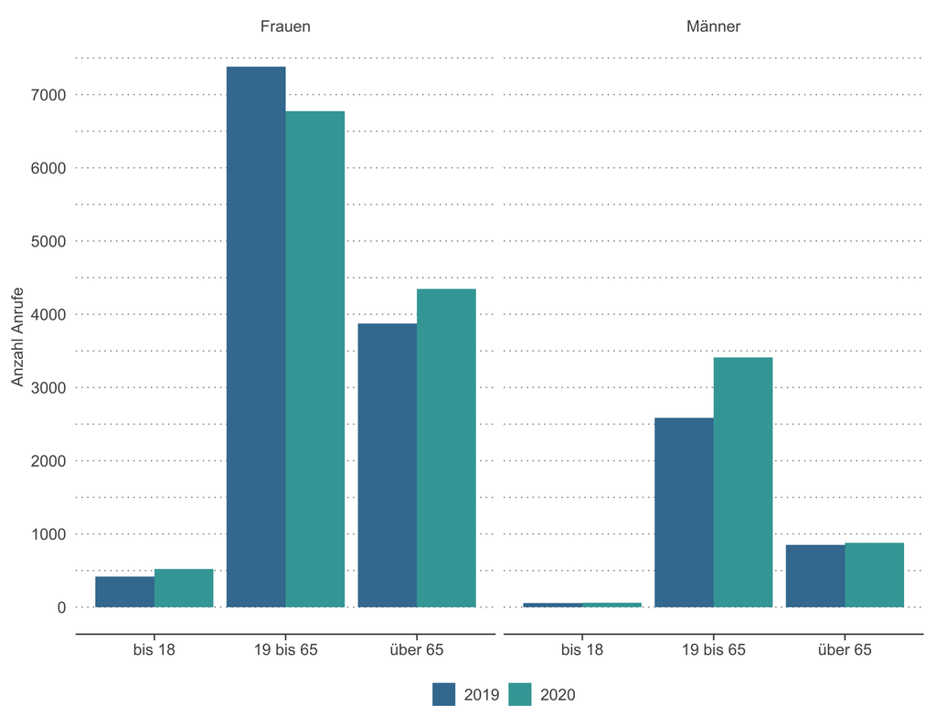

## Immer noch dieselben Themen

Bei jedem Anruf notieren die Mitarbeiter und Mitarbeiterinnen des Sorgentelefons die angesprochenen Beratungsinhalte. Pro Anruf können natürlich mehrere Themen zur Sprache kommen, im Schnitt sind es zwei.

Die während der Beratungsgespräche am häufigsten angesprochenen Themen sind «Alltagsbewältigung», «Psychisches Leiden» und «Einsamkeit». Diese drei Themen machen zusammen fast 60% der Beratungsinhalte aus, und daran hat sich im Vergleich zum Vorjahr auch nichts geändert.

Eindrücklich ist die Veränderung beim Thema «Suchtverhalten»: Die über 65-Jährigen riefen im ersten Halbjahr 2020 deswegen mehr als dreimal so häufig an wie im Vorjahr, während die Zahl der Anrufe bei den übrigen Altersklassen stabil blieb. Ein möglicher Erklärungsansatz sind die Verhaltensempfehlungen der Behörden wegen der Pandemie. Angehörige der Risikogruppe, zu der Menschen im Pensionsalter gehören, wurden aufgefordert, zuhause zu bleiben und zwischenmenschliche Kontakte möglichst zu meiden. Diese «verordnete» Isolation dürfte bei vielen älteren Menschen ein Gefühl der Einsamkeit geweckt haben, dem sie wiederum mit Suchtmitteln zu begegnen versuchten.

[figure not shown]

# Hinweis

Bei den Kategorien Geschlecht und Alter gibt es jeweils die Merkmal «nicht bestimmbar». Dies bedeutet, dass die Anrufenden ihr Geschlecht und/oder Alter nicht angegeben haben. Insgesamt machen diese Anrufe sowohl 2019 als auch 2020 weniger als 2% aus. Werden die Kategorien jedoch miteinander oder mit bestimmten Beratungsinhalten gekreuzt, kann der Anteil auf bis zu 20% steigen. Diese Fälle wurden aus der Analyse ausgeschlossen. Dasselbe gilt für die Kategorie «divers» beim Geschlecht, die insgesamt zwei Anrufe betrifft. In den Rohdaten sind jedoch alle Kategorien enthalten.

# Datengrundlage und Reproduzierbarkeit

Die Daten und der Quellcode für diese Mitteilung stehen öffentlich auf [GitHub](https://github.com/statistikZH/covid19monitoring_social_Tel143) zur Verfügung.